# Big Mart Sales Prediction

## Introduction

### Problem Statement

The data scientists at BigMart have collected 2013 sales data for 1559 products across 10 stores in different cities. Also, certain attributes of each product and store have been defined. The aim is to build a predictive model and find out the sales of each product at a particular store.

Using this model, BigMart will try to understand the properties of products and stores which play a key role in increasing sales.

Please note that the data may have missing values as some stores might not report all the data due to technical glitches. Hence, it will be required to treat them accordingly.

### Data sets

We have train (8523) and test (5681) data set, train data set has both input and output variable(s). The goal is to predict the sales for test data set.

## Load the data and the libraries

The needed libraries are loaded.

```r
library(caret)
library(dplyr)
library(reshape2)
library(elasticnet)
library(glmnet)
library(rpart)
library(randomForest)
library(ranger)
library(xgboost)
```

The train and test data sets are loaded.

```r
train <- read.csv("TrainSales.csv",header = TRUE, na.strings = "")
test <- read.csv("TestSales.csv", header = TRUE, na.strings = "")
```

## Explore the data

We combine the train and test data.

```r
train2 <- train
test2 <- test
test2$Item_Outlet_Sales <- rep(NA, times = 5681)
comb2 <- rbind(train2,test2)
```

The number of missing values of every variable is calculated.

```r
temp <- lapply(comb2, is.na)
sapply(temp, sum)
```

```
##           Item_Identifier               Item_Weight
##                         0                      2439
##          Item_Fat_Content           Item_Visibility
##                         0                         0
##                 Item_Type                  Item_MRP
##                         0                         0
##         Outlet_Identifier Outlet_Establishment_Year
##                         0                         0
##               Outlet_Size      Outlet_Location_Type
##                      4016                         0
##               Outlet_Type         Item_Outlet_Sales
##                         0                      5681
```

The Item_Outlet_Sales is the target variable for prediction, and as a result the missing values are from the test data set. It can be seen that the Item_Weight and Outlet_Size variables have some missing values, which need imputing.

```r
str(comb2)
```

```
## 'data.frame':    14204 obs. of  12 variables:
##  $ Item_Identifier          : Factor w/ 1559 levels "DRA12","DRA24",..: 157 9 663 1122 1298 759 697 739 441 991 ...
##  $ Item_Weight              : num  9.3 5.92 17.5 19.2 8.93 ...
##  $ Item_Fat_Content         : Factor w/ 5 levels "LF","low fat",..: 3 5 3 5 3 5 5 3 5 5 ...
##  $ Item_Visibility          : num  0.016 0.0193 0.0168 0 0 ...
##  $ Item_Type                : Factor w/ 16 levels "Baking Goods",..: 5 15 11 7 10 1 14 14 6 6 ...
##  $ Item_MRP                 : num  249.8 48.3 141.6 182.1 53.9 ...
##  $ Outlet_Identifier        : Factor w/ 10 levels "OUT010","OUT013",..: 10 4 10 1 2 4 2 6 8 3 ...
##  $ Outlet_Establishment_Year: int  1999 2009 1999 1998 1987 2009 1987 1985 2002 2007 ...
##  $ Outlet_Size              : Factor w/ 3 levels "High","Medium",..: 2 2 2 NA 1 2 1 2 NA NA ...
##  $ Outlet_Location_Type     : Factor w/ 3 levels "Tier 1","Tier 2",..: 1 3 1 3 3 3 3 3 2 2 ...
##  $ Outlet_Type              : Factor w/ 4 levels "Grocery Store",..: 2 3 2 1 2 3 2 4 2 2 ...
##  $ Item_Outlet_Sales        : num  3735 443 2097 732 995 ...
```

We summarize and examine the numerical variables of the data set.

```r
num_vars <- c("Item_Weight", "Item_Visibility","Item_MRP","Outlet_Establishment_Year","Item_Outlet_Sales")
summary(comb2[,num_vars])
```

```
##   Item_Weight     Item_Visibility      Item_MRP
##  Min.   : 4.555   Min.   :0.00000   Min.   : 31.29
##  1st Qu.: 8.710   1st Qu.:0.02704   1st Qu.: 94.01
##  Median :12.600   Median :0.05402   Median :142.25
##  Mean   :12.793   Mean   :0.06595   Mean   :141.00
##  3rd Qu.:16.750   3rd Qu.:0.09404   3rd Qu.:185.86
##  Max.   :21.350   Max.   :0.32839   Max.   :266.89
##  NA's   :2439
##  Outlet_Establishment_Year Item_Outlet_Sales
##  Min.   :1985              Min.   :   33.29
##  1st Qu.:1987              1st Qu.:  834.25
##  Median :1999              Median : 1794.33
##  Mean   :1998              Mean   : 2181.29
##  3rd Qu.:2004              3rd Qu.: 3101.30
##  Max.   :2009              Max.   :13086.97
##                            NA's   :5681
```

We explore the categorical variables of the data set. We see how many unique values has each categorical variable. We make a frequency table of the variables, excluding the Item_Identifier and Outlet_Identifier variables.

```r
summary(comb2[,!(colnames(comb2) %in% num_vars)])
```

```
##  Item_Identifier Item_Fat_Content                 Item_Type
##  DRA24  :   10   LF     : 522     Fruits and Vegetables:2013
##  DRA59  :   10   low fat: 178     Snack Foods          :1989
##  DRB25  :   10   Low Fat:8485     Household            :1548
##  DRC25  :   10   reg    : 195     Frozen Foods         :1426
##  DRC27  :   10   Regular:4824     Dairy                :1136
##  DRC36  :   10                    Baking Goods         :1086
##  (Other):14144                    (Other)              :5006
##  Outlet_Identifier Outlet_Size   Outlet_Location_Type
##  OUT027 :1559      High  :1553   Tier 1:3980
##  OUT013 :1553      Medium:4655   Tier 2:4641
##  OUT035 :1550      Small :3980   Tier 3:5583
##  OUT046 :1550      NA's  :4016
##  OUT049 :1550
##  OUT045 :1548
##  (Other):4894
##             Outlet_Type
##  Grocery Store    :1805
##  Supermarket Type1:9294
##  Supermarket Type2:1546
##  Supermarket Type3:1559
##
##
##
```

```r
v<- sapply(comb2[,!(colnames(comb2) %in% num_vars)], unique)
sapply(v, length)
```

```
##      Item_Identifier     Item_Fat_Content            Item_Type
##                 1559                    5                   16
##    Outlet_Identifier          Outlet_Size Outlet_Location_Type
##                   10                    4                    3
##          Outlet_Type
##                    4
```

```r
lapply((comb2[,!(colnames(comb2) %in% num_vars | colnames(comb2) %in% c("Item_Identifier", "Outlet_Identifier"))]), table)
```

```
## $Item_Fat_Content
##
##      LF low fat Low Fat     reg Regular
##     522     178    8485     195    4824
##
## $Item_Type
##
##          Baking Goods                Breads             Breakfast
##                  1086                   416                   186
##                Canned                 Dairy          Frozen Foods
##                  1084                  1136                  1426
## Fruits and Vegetables           Hard Drinks    Health and Hygiene
##                  2013                   362                   858
##             Household                  Meat                Others
##                  1548                   736                   280
##               Seafood           Snack Foods           Soft Drinks
##                    89                  1989                   726
##         Starchy Foods
##                   269
##
## $Outlet_Size
##
##   High Medium  Small
##   1553   4655   3980
##
## $Outlet_Location_Type
##
## Tier 1 Tier 2 Tier 3
##   3980   4641   5583
##
## $Outlet_Type
##
##     Grocery Store Supermarket Type1 Supermarket Type2 Supermarket Type3
##              1805              9294              1546              1559
```

Observations:

1. In the Item_Fat_Content variable, some “Low Fat” products have been miscoded as “low fat” or “LF”, while some “Regular” products have been miscoded as “reg”.
2. In the Item_Type variable, not all categories have substantial numbers. Combining them may give better results.

## Clean the data

### Impute the missing values

There are two variables with missing values: Item_Weight and Outlet_Size.

#### Item_Weight

The missing values of the Item_Weight variable are going to be imputed with the average weigth for the particular item.

```r
## We find the average weight for each Item.
AvweightByItem <- aggregate(Item_Weight~Item_Identifier, data = comb2, mean)

## Impute the missing values
for(i in 1:(dim(comb2)[1]))
{
        if(is.na(comb2$Item_Weight[i])){
                pr <- comb2$Item_Identifier[i]
                comb2$Item_Weight[i] <-  AvweightByItem[pr,2]
        }
}
sum(is.na(comb2$Item_Weight))
```

```
## [1] 0
```

#### Outlet_Size

The missing values of the Outlet_Size variable will be imputed with the appropriate size respective of the Outlet_Type.

```r
t <- table(comb2$Outlet_Type, comb2$Outlet_Size)

for (i in 1:(dim(comb2)[1])){
        if(is.na(comb2$Outlet_Size[i])){
                if(comb2$Outlet_Type[i] == "Grocery Store"){
                        comb2$Outlet_Size[i] <- "Small"
                }
                else if(comb2$Outlet_Type[i] == "Supermarket Type1"){
                        comb2$Outlet_Size[i] <- sample(c("High","Medium",
                                                         "Small"),size = 1,
                                                       replace = TRUE, prob = c(t["Supermarket Type1",1]/sum(t["Supermarket Type1",]),
                                                                                (t["Supermarket Type1",2]/sum(t["Supermarket Type1",])),
                                                                                (t["Supermarket Type1",3]/sum(t["Supermarket Type1",]))))

                }
                else if(comb2$Item_Type[i] == "Supermarket Type2"|comb2$Item_Type[i] == "Supermarket Type3"){
                        comb2$Outlet_Size[i] <- "Medium"
                }

                }
}

sum(is.na(comb2$Outlet_Size))
```

```
## [1] 0
```

```r
table(comb2$Outlet_Size, comb2$Outlet_Type)
```

```
##
##          Grocery Store Supermarket Type1 Supermarket Type2
##   High               0              2344                 0
##   Medium             0              2316              1546
##   Small           1805              4634                 0
##
##          Supermarket Type3
##   High                   0
##   Medium              1559
##   Small                  0
```

## Feature Engineering

### Item_Visibility Modify

```r
summary(comb2$Item_Visibility)
```

```
##    Min. 1st Qu.  Median    Mean 3rd Qu.    Max.
## 0.00000 0.02704 0.05402 0.06595 0.09404 0.32839
```

It can be seen that the minimum value of the Item_Visibility variable is 0, which is not logical, as it makes no sense to have an item in a store without displaying it. The zeros in the variable values will be considered as missing values and will be imputed with the mean visibility of the product.

```r
## We find the average visibility for each Item.
AvVisibilityByItem <- aggregate(Item_Visibility~Item_Identifier, data = comb2, mean)

## Impute the missing values
for(i in 1:(dim(comb2)[1]))
{
        if(comb2$Item_Visibility[i] == 0){
                pr2 <- comb2$Item_Identifier[i]
                comb2$Item_Visibility[i] <-  AvVisibilityByItem[pr,2]
        }
}
sum(which(comb2$Item_Visibility == 0))
```

```
## [1] 0
```

A new variable is created which represents the ratio of the mean value of the visibility of an item in a particular store over the mean visibility of the item in general and it is named Item_Visibility_Means_ratio.

```r
comb2$Item_Visibility_Means_ratio <- rep(0, times = dim(comb2)[1])

for(i in 1:(dim(comb2)[1])){
        comb2$Item_Visibility_Means_ratio[i] <- (comb2[i,"Item_Visibility"])/(AvVisibilityByItem[AvVisibilityByItem$Item_Identifier == comb2$Item_Identifier[i],"Item_Visibility"])
}
```

### Create variable Item_Type_General (a new variable with broader Item type categories)

A new varaible is created with the name of Item_Type_General, which will be a broader type of product variable, with the values “Food”, “Drinks” and “Non-Concumable”, and will be constructed using the first letters of the Item_Identifier variable.

```r
comb2$Item_Type_General <- rep("a", times = dim(comb2)[1])

for(i in 1:(dim(comb2)[1])){
        if(startsWith(as.character(comb2$Item_Identifier[i]),"FD")){
                comb2$Item_Type_General[i] <- "Food"
        }
        else if(startsWith(as.character(comb2$Item_Identifier[i]),"DR")){
                comb2$Item_Type_General[i] <- "Drinks"
        }
        else if(startsWith(as.character(comb2$Item_Identifier[i]),"NC")){
                comb2$Item_Type_General[i] <- "Non-Consumable"
        }
}
```

### Item_Fat_Contents Modify

Even though there are five values for this variable, it actually has two categories: “Low Fat” and “Regular”. The existance of five values is because of different represantation of the same value. Products that are “Low Fat” have been categorised ,in a wrong way, as “low fat” and “LF” also and some products that are “Regular” have been categorised mistakenly as “reg”.

Also, a new category should be made as there are some products that are not consumable. The new catgory will be “Non-Edible”.

```r
comb2$Item_Fat_Content <- as.character(comb2$Item_Fat_Content)

for(i in 1:(dim(comb2)[1])){
        if(startsWith(as.character(comb2$Item_Identifier[i]),"NC")){
                comb2$Item_Fat_Content[i] <- "Non-Edible"

        }
        else{
                if(comb2$Item_Fat_Content[i]=="low fat" | comb2$Item_Fat_Content[i] == "LF"){
                        comb2$Item_Fat_Content[i] <- "Low Fat"
                }
                else if(comb2$Item_Fat_Content[i] == "reg"){
                        comb2$Item_Fat_Content[i] <- "Regular"
                }
        }
}
comb2$Item_Fat_Content <- as.factor(comb2$Item_Fat_Content)
```

### Create variable Years_Operate

Years_Operate is a new variable which represents the time in yars that a store has benn perated.

```r
comb2$Years_Operate <- 2013 - comb2$Outlet_Establishment_Year
```

### New variale Outlet

New variable Outlet is created with levels 0 - 9,same as the Outlet_Identifier.

```r
comb2$Outlet <- comb2$Outlet_Identifier
levels(comb2$Outlet)<- 0:9
summary(comb2$Outlet)
```

```
##    0    1    2    3    4    5    6    7    8    9
##  925 1553 1543 1546  880 1559 1550 1548 1550 1550
```

### One hot coding of the categorical variables

One hot coding of the categorical variables in a new data frame.

```r
comb2$Outlet <- comb2$Outlet_Identifier
levels(comb2$Outlet)<- 0:9

comb3 <- comb2
levels(comb3$Outlet_Location_Type) <- 1:3
levels(comb3$Outlet_Type) <- 0:3
dm <- dummyVars(~ Item_Fat_Content + Outlet_Size + Outlet_Location_Type +
                        Outlet_Type+Item_Type_General+ Outlet, data = comb3)
tr <- data.frame(predict(dm, newdata = comb3))

dum <- c("Item_Fat_Content", "Outlet_Size", "Outlet_Location_Type",
                 "Outlet_Type", "Item_Type_General", "Outlet")
comb4 <- cbind(comb3[,!(colnames(comb3) %in% dum)],tr)
comb4 <- comb4[,-c(4,7)]
```

## Seperate the data in training and testing data

```r
train4 <- comb4[!(is.na(comb4$Item_Outlet_Sales)),]
test4 <- comb4[is.na(comb4$Item_Outlet_Sales),]

test4$Item_Outlet_SalesN <- test4$Item_Outlet_Sales
test4 <- test4[,-6]
train4$Item_Outlet_SalesN <- train$Item_Outlet_Sales
train4 <- train4[,-6]
test4 <- test4[,-34]
train4$Item_Outlet_Sales <- train4$Item_Outlet_SalesN
train4<- train4[,-34]
```

## Seperate the training data for cross - validation.

```r
inTrain <- createDataPartition(train4$Item_Outlet_Sales, p = 0.75, list = FALSE)
train4tr <- train4[inTrain,]
train4te <- train4[-inTrain,]
```

## Model Building

### Baseline model

A baseline model is made using the mean of the overall sales.

```r
bmodel_meanS <- mean(train4tr$Item_Outlet_Sales)
bmodel_meanS_pred <- rep(bmodel_meanS, times = dim(train4tr)[1])
rmsetrS <- sqrt(mean((bmodel_meanS_pred - train4tr$Item_Outlet_Sales)^2))
rmsetrS
```

```
## [1] 1693.855
```

```r
bmodel_meanS_predte <- rep(bmodel_meanS, times = dim(train4te)[1])
rmsetrSte <- sqrt(mean((bmodel_meanS_predte - train4te$Item_Outlet_Sales)^2))
rmsetrSte
```

```
## [1] 1743.549
```

A baseline model is made using the mean of the sales of each product.

```r
bmodel_mean <- aggregate(Item_Outlet_Sales ~ Item_Identifier, data = train4tr, mean)

bmodel_mean_predtr <- rep(0, times = dim(train4tr)[1])
for(i in 1:(dim(train4tr)[1])){
        bmodel_mean_predtr[i]<- bmodel_mean[bmodel_mean$Item_Identifier == train4tr$Item_Identifier[i],"Item_Outlet_Sales"]

}
rmsetr <- sqrt(mean((bmodel_mean_predtr-train4tr$Item_Outlet_Sales)^2))
rmsetr
```

```
## [1] 1230.095
```

```r
bmodel_mean_predte <- rep(0, times = dim(train4te)[1])
for(i in 1:(dim(train4te)[1])){
        pr3 <- train4te$Item_Identifier[i]
        bmodel_mean_predte[i]<- bmodel_mean[pr3,"Item_Outlet_Sales"]

}
sum(is.na(bmodel_mean_predte))
```

```
## [1] 10
```

```r
for(i in 1:length(bmodel_mean_predte)){
        if(is.na(bmodel_mean_predte[i]))
        {bmodel_mean_predte[i]<- 0}
}
sum(is.na(bmodel_mean_predte))
```

```
## [1] 0
```

```r
rmsete <- sqrt(mean((bmodel_mean_predte-train4te$Item_Outlet_Sales)^2))
rmsete
```

```
## [1] 2091.939
```

### Linear Regression Model

We make a linear regression model for our data. We firstly create a new split of data without the dummy variables.

```r
comb3 <- comb3[,-c(5,8)]
Item_Outlet_Sales <- comb3$Item_Outlet_Sales
comb3 <- comb3[,-10]
comb3$Item_Outlet_Sales <- Item_Outlet_Sales

train3 <- comb3[!(is.na(comb3$Item_Outlet_Sales)),]
test3 <- comb3[is.na(comb3$Item_Outlet_Sales),]
train3$Item_Type_General <- as.factor(train3$Item_Type_General)
test3$Item_Type_General <- as.factor(test3$Item_Type_General)
train3te <- train3[-inTrain,]
train3tr <- train3[inTrain,]
```

We fit our model to all the variables except thse that are identifiers.

```r
control <- trainControl(method = "cv", number = 10)

set.seed(2207)
model_lin <- train(Item_Outlet_Sales ~ . -Item_Identifier -Outlet_Identifier
                   -Outlet, data = train3tr,trControl = control,method = "lm",
                   metric = "RMSE")
summary(model_lin)
```

```
##
## Call:
## lm(formula = .outcome ~ ., data = dat)
##
## Residuals:
##     Min      1Q  Median      3Q     Max
## -4298.0  -671.8   -92.3   578.6  6784.8
##
## Coefficients: (1 not defined because of singularities)
##                                    Estimate Std. Error t value Pr(>|t|)
## (Intercept)                       -1647.386    172.726  -9.538   <2e-16
## Item_Weight                          -2.199      3.033  -0.725    0.469
## `Item_Fat_ContentNon-Edible`        -24.662     56.301  -0.438    0.661
## Item_Fat_ContentRegular              47.315     32.525   1.455    0.146
## Item_Visibility                    -122.045    302.490  -0.403    0.687
## Item_MRP                             15.479      0.226  68.479   <2e-16
## Outlet_SizeMedium                   -94.028     73.661  -1.277    0.202
## Outlet_SizeSmall                    -66.004     61.740  -1.069    0.285
## Outlet_Location_Type2               -24.682     59.530  -0.415    0.678
## Outlet_Location_Type3               -19.528     57.917  -0.337    0.736
## Outlet_Type1                       1927.459     62.228  30.974   <2e-16
## Outlet_Type2                       1594.710    103.289  15.439   <2e-16
## Outlet_Type3                       3434.102     93.633  36.676   <2e-16
## Item_Visibility_Means_ratio          16.930     19.096   0.887    0.375
## Item_Type_GeneralFood               -32.410     50.396  -0.643    0.520
## `Item_Type_GeneralNon-Consumable`        NA         NA      NA       NA
## Years_Operate                        -3.959      4.444  -0.891    0.373
##
## (Intercept)                       ***
## Item_Weight
## `Item_Fat_ContentNon-Edible`
## Item_Fat_ContentRegular
## Item_Visibility
## Item_MRP                          ***
## Outlet_SizeMedium
## Outlet_SizeSmall
## Outlet_Location_Type2
## Outlet_Location_Type3
## Outlet_Type1                      ***
## Outlet_Type2                      ***
## Outlet_Type3                      ***
## Item_Visibility_Means_ratio
## Item_Type_GeneralFood
## `Item_Type_GeneralNon-Consumable`
## Years_Operate
## ---
## Signif. codes:  0 '***' 0.001 '**' 0.01 '*' 0.05 '.' 0.1 ' ' 1
##
## Residual standard error: 1120 on 6378 degrees of freedom
## Multiple R-squared:  0.5636, Adjusted R-squared:  0.5625
## F-statistic:   549 on 15 and 6378 DF,  p-value: < 2.2e-16
```

```r
model_lin
```

```
## Linear Regression
##
## 6394 samples
##   13 predictor
##
## No pre-processing
## Resampling: Cross-Validated (10 fold)
## Summary of sample sizes: 5755, 5755, 5755, 5755, 5754, 5755, ...
## Resampling results:
##
##   RMSE      Rsquared   MAE
##   1121.006  0.5626318  835.0593
##
## Tuning parameter 'intercept' was held constant at a value of TRUE
```

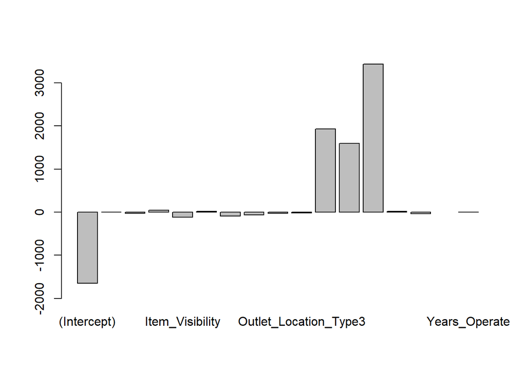

```r
barplot(model_lin$finalModel$coefficients, ylim = c(-2000, 3500))
```

We exclude the Outlet and Item_Fat_Content because of some warning we got.

```r
set.seed(2207)
model_lin2 <- train(Item_Outlet_Sales ~ . -Item_Identifier -Outlet_Identifier
                   -Item_Fat_Content -Outlet, data = train3tr,
                   trControl = control,method = "lm", metric = "RMSE")
summary(model_lin2)
```

```
##
## Call:
## lm(formula = .outcome ~ ., data = dat)
##
## Residuals:
##     Min      1Q  Median      3Q     Max
## -4272.6  -670.4   -83.9   578.5  6811.0
##
## Coefficients:
##                                     Estimate Std. Error t value Pr(>|t|)
## (Intercept)                       -1645.3164   172.7357  -9.525   <2e-16
## Item_Weight                          -2.2722     3.0327  -0.749    0.454
## Item_Visibility                    -109.4438   302.3924  -0.362    0.717
## Item_MRP                             15.4757     0.2261  68.461   <2e-16
## Outlet_SizeMedium                   -93.1079    73.6643  -1.264    0.206
## Outlet_SizeSmall                    -64.3179    61.7350  -1.042    0.298
## Outlet_Location_Type2               -25.2799    59.5342  -0.425    0.671
## Outlet_Location_Type3               -18.9644    57.9213  -0.327    0.743
## Outlet_Type1                       1928.5175    62.2290  30.991   <2e-16
## Outlet_Type2                       1595.0062   103.2978  15.441   <2e-16
## Outlet_Type3                       3433.9069    93.6416  36.671   <2e-16
## Item_Visibility_Means_ratio          16.9872    19.0981   0.889    0.374
## Item_Type_GeneralFood               -13.2854    48.6552  -0.273    0.785
## `Item_Type_GeneralNon-Consumable`   -27.8644    56.2630  -0.495    0.620
## Years_Operate                        -3.9677     4.4438  -0.893    0.372
##
## (Intercept)                       ***
## Item_Weight
## Item_Visibility
## Item_MRP                          ***
## Outlet_SizeMedium
## Outlet_SizeSmall
## Outlet_Location_Type2
## Outlet_Location_Type3
## Outlet_Type1                      ***
## Outlet_Type2                      ***
## Outlet_Type3                      ***
## Item_Visibility_Means_ratio
## Item_Type_GeneralFood
## `Item_Type_GeneralNon-Consumable`
## Years_Operate
## ---
## Signif. codes:  0 '***' 0.001 '**' 0.01 '*' 0.05 '.' 0.1 ' ' 1
##
## Residual standard error: 1121 on 6379 degrees of freedom
## Multiple R-squared:  0.5634, Adjusted R-squared:  0.5625
## F-statistic:   588 on 14 and 6379 DF,  p-value: < 2.2e-16
```

```r
model_lin2
```

```
## Linear Regression
##
## 6394 samples
##   13 predictor
##
## No pre-processing
## Resampling: Cross-Validated (10 fold)
## Summary of sample sizes: 5755, 5755, 5755, 5755, 5754, 5755, ...
## Resampling results:
##
##   RMSE      Rsquared  MAE
##   1120.893  0.562729  834.7685
##
## Tuning parameter 'intercept' was held constant at a value of TRUE
```

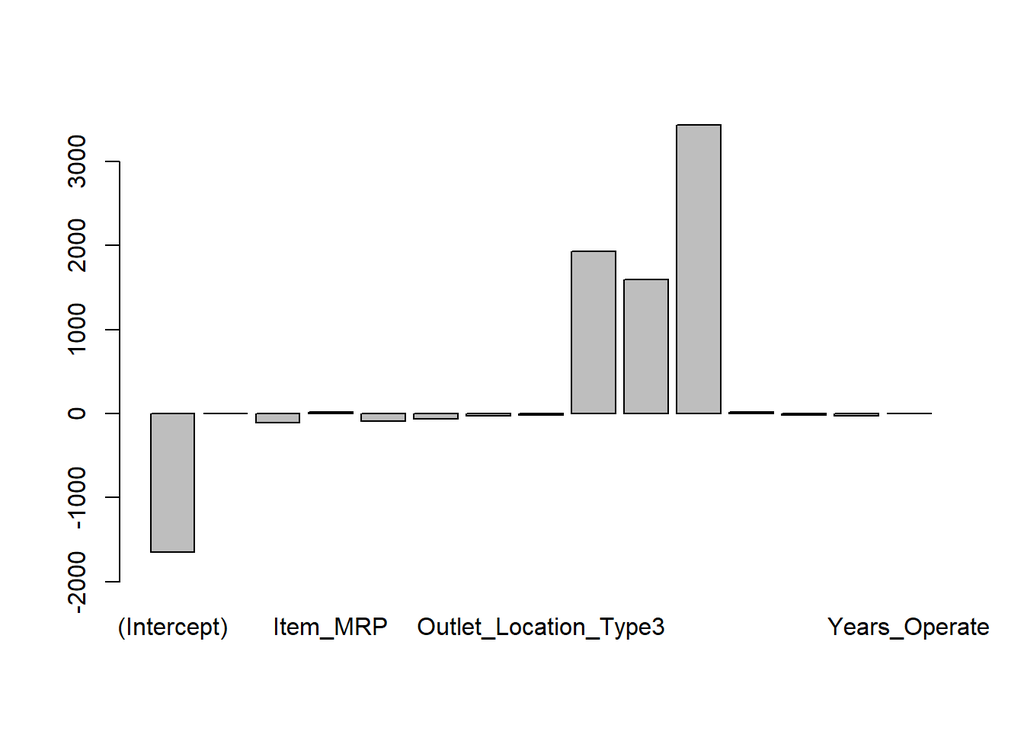

```r
barplot(model_lin2$finalModel$coefficients, ylim = c(-2000, 3500))
```

A variable selection process is made to choose the most apropriate variables for the model. A backwards selection process is attempted, using the AIC (Akaike Information Criterion).

```r
fil_l <- lm(Item_Outlet_Sales ~ . -Item_Identifier -Outlet_Identifier,
            data = train3tr, metric = "RMSE")
bestmod <- step(fil_l, direction = "backward")
```

```
## Start:  AIC=89789.22
## Item_Outlet_Sales ~ (Item_Identifier + Item_Weight + Item_Fat_Content +
##     Item_Visibility + Item_MRP + Outlet_Identifier + Outlet_Size +
##     Outlet_Location_Type + Outlet_Type + Item_Visibility_Means_ratio +
##     Item_Type_General + Years_Operate + Outlet) - Item_Identifier -
##     Outlet_Identifier
```

```
##
## Step:  AIC=89789.22
## Item_Outlet_Sales ~ Item_Weight + Item_Fat_Content + Item_Visibility +
##     Item_MRP + Outlet_Size + Outlet_Location_Type + Outlet_Type +
##     Item_Visibility_Means_ratio + Item_Type_General + Outlet
```

```
##
## Step:  AIC=89789.22
## Item_Outlet_Sales ~ Item_Weight + Item_Fat_Content + Item_Visibility +
##     Item_MRP + Outlet_Size + Outlet_Location_Type + Item_Visibility_Means_ratio +
##     Item_Type_General + Outlet
```

```
##
## Step:  AIC=89789.22
## Item_Outlet_Sales ~ Item_Weight + Item_Fat_Content + Item_Visibility +
##     Item_MRP + Outlet_Size + Item_Visibility_Means_ratio + Item_Type_General +
##     Outlet
##
##                               Df  Sum of Sq        RSS   AIC
## - Item_Visibility              1     209103 7.9778e+09 89787
## - Item_Type_General            1     663094 7.9783e+09 89788
## - Item_Weight                  1     763436 7.9784e+09 89788
## - Item_Visibility_Means_ratio  1    1047534 7.9786e+09 89788
## <none>                                      7.9776e+09 89789
## - Item_Fat_Content             1    2815588 7.9804e+09 89789
## - Outlet_Size                  2    6299349 7.9839e+09 89790
## - Outlet                       9 3187966134 1.1166e+10 91921
## - Item_MRP                     1 5878916573 1.3857e+10 93317
```

```
##
## Step:  AIC=89787.38
## Item_Outlet_Sales ~ Item_Weight + Item_Fat_Content + Item_MRP +
##     Outlet_Size + Item_Visibility_Means_ratio + Item_Type_General +
##     Outlet
##
##                               Df  Sum of Sq        RSS   AIC
## - Item_Type_General            1     673895 7.9785e+09 89786
## - Item_Weight                  1     744516 7.9785e+09 89786
## - Item_Visibility_Means_ratio  1    1028591 7.9788e+09 89786
## <none>                                      7.9778e+09 89787
## - Item_Fat_Content             1    2773893 7.9806e+09 89788
## - Outlet_Size                  2    6303985 7.9841e+09 89788
## - Outlet                       9 3371974366 1.1350e+10 92023
## - Item_MRP                     1 5878739645 1.3857e+10 93315
```

```
##
## Step:  AIC=89785.92
## Item_Outlet_Sales ~ Item_Weight + Item_Fat_Content + Item_MRP +
##     Outlet_Size + Item_Visibility_Means_ratio + Outlet
##
##                               Df  Sum of Sq        RSS   AIC
## - Item_Fat_Content             2    2429566 7.9809e+09 89784
## - Item_Weight                  1     802994 7.9793e+09 89785
## - Item_Visibility_Means_ratio  1    1043768 7.9795e+09 89785
## <none>                                      7.9785e+09 89786
## - Outlet_Size                  2    6301810 7.9848e+09 89787
## - Outlet                       9 3371674352 1.1350e+10 92022
## - Item_MRP                     1 5881449681 1.3860e+10 93315
```

```
##
## Step:  AIC=89783.87
## Item_Outlet_Sales ~ Item_Weight + Item_MRP + Outlet_Size + Item_Visibility_Means_ratio +
##     Outlet
##
##                               Df  Sum of Sq        RSS   AIC
## - Item_Weight                  1     870739 7.9818e+09 89783
## - Item_Visibility_Means_ratio  1    1022997 7.9819e+09 89783
## <none>                                      7.9809e+09 89784
## - Outlet_Size                  2    6295073 7.9872e+09 89785
## - Outlet                       9 3370914629 1.1352e+10 92019
## - Item_MRP                     1 5881740880 1.3863e+10 93312
```

```
##
## Step:  AIC=89782.57
## Item_Outlet_Sales ~ Item_MRP + Outlet_Size + Item_Visibility_Means_ratio +
##     Outlet
##
##                               Df  Sum of Sq        RSS   AIC
## - Item_Visibility_Means_ratio  1    1047886 7.9828e+09 89781
## <none>                                      7.9818e+09 89783
## - Outlet_Size                  2    6254594 7.9880e+09 89784
## - Outlet                       9 3372326959 1.1354e+10 92018
## - Item_MRP                     1 5882225681 1.3864e+10 93311
```

```
##
## Step:  AIC=89781.41
## Item_Outlet_Sales ~ Item_MRP + Outlet_Size + Outlet
##
##               Df  Sum of Sq        RSS   AIC
## <none>                      7.9828e+09 89781
## - Outlet_Size  2    6217354 7.9890e+09 89782
## - Outlet       9 3502486106 1.1485e+10 92089
## - Item_MRP     1 5881275689 1.3864e+10 93309
```

```r
set.seed(2207)
model_lin3 <- train(Item_Outlet_Sales ~ Item_Fat_Content + Item_MRP + Outlet,
                    data = train3tr,trControl = control,method = "lm",
                    metric = "RMSE")
model_lin3
```

```
## Linear Regression
##
## 6394 samples
##    3 predictor
##
## No pre-processing
## Resampling: Cross-Validated (10 fold)
## Summary of sample sizes: 5755, 5755, 5755, 5755, 5754, 5755, ...
## Resampling results:
##
##   RMSE      Rsquared   MAE
##   1119.271  0.5640275  834.8233
##
## Tuning parameter 'intercept' was held constant at a value of TRUE
```

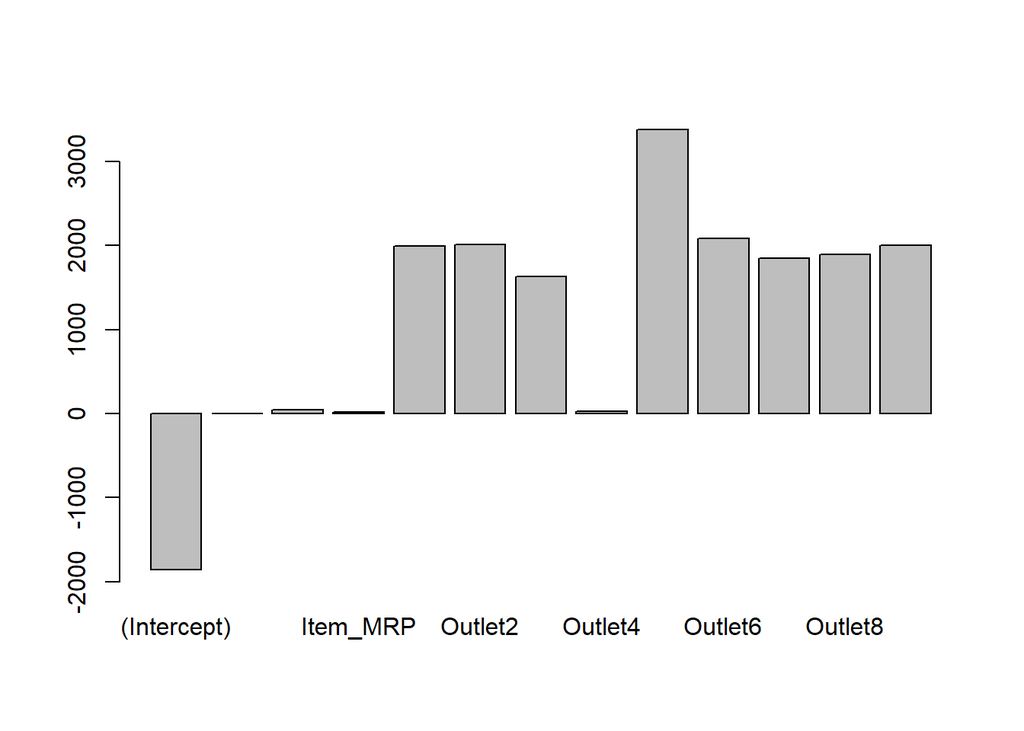

```r
barplot(model_lin3$finalModel$coefficients, ylim = c(-2000, 3500))
```

We can see that the three linear models we tried are mostly similar, with the last one to be a little better. We use this model to predict the values of Item_Outlet_Sales of the test partition of the training data set “train3te” and find the RMSE between the predictions and the actual observations.

```r
pred_lin3 <- predict(model_lin3, newdata = train3te)
RMSE(pred_lin3, train3te$Item_Outlet_Sales)
```

```
## [1] 1157.481
```

### Ridge and Lasso Models

#### Ridge

We make a model used regularised regression ridge technique.

```r
set.seed(2207)
ridge <- train(Item_Outlet_Sales ~. -Item_Identifier -Outlet_Identifier,
               data = train3tr, method='ridge',lambda = 4)
ridge.pred <- predict(ridge, train3te)
RMSE(ridge.pred,train4te$Item_Outlet_Sales)
```

```
## [1] 1157.592
```

We tune the lambda value

```r
set.seed(2207)
fitControl <- trainControl(method = "cv", number = 10)
lambdaGrid <- expand.grid(lambda = 10^seq(10, -2, length=100))

set.seed(2207)
ridge2 <- train(Item_Outlet_Sales~. -Item_Identifier -Outlet_Identifier,
               data = train3tr, method='ridge',trControl = fitControl,
               tuneGrid = lambdaGrid)
ridge2.pred <- predict(ridge2, train3te)
RMSE(ridge2.pred,train4te$Item_Outlet_Sales)
```

```
## [1] 1158.056
```

```r
ridge2
```

```
## Ridge Regression
##
## 6394 samples
##   13 predictor
##
## No pre-processing
## Resampling: Cross-Validated (10 fold)
## Summary of sample sizes: 5755, 5755, 5755, 5755, 5754, 5755, ...
## Resampling results across tuning parameters:
##
##   lambda        RMSE      Rsquared   MAE
##   1.000000e-02  1119.566  0.5637847   835.0010
##   1.321941e-02  1119.716  0.5636636   835.1847
##   1.747528e-02  1119.957  0.5634712   835.4749
##   2.310130e-02  1120.332  0.5631733   835.9240
##   3.053856e-02  1120.897  0.5627255   836.5592
##   4.037017e-02  1121.718  0.5620754   837.4365
##   5.336699e-02  1122.864  0.5611676   838.6558
##   7.054802e-02  1124.402  0.5599503   840.2683
##   9.326033e-02  1126.386  0.5583829   842.3669
##   1.232847e-01  1128.861  0.5564376   844.9662
##   1.629751e-01  1131.877  0.5540947   848.0723
##   2.154435e-01  1135.515  0.5513297   851.8743
##   2.848036e-01  1139.922  0.5480986   856.6065
##   3.764936e-01  1145.343  0.5443277   862.2877
##   4.977024e-01  1152.156  0.5399109   869.4524
##   6.579332e-01  1160.874  0.5347213   878.3093
##   8.697490e-01  1172.127  0.5286354   889.1850
##   1.149757e+00  1186.578  0.5215712   902.4587
##   1.519911e+00  1204.787  0.5135292   918.6007
##   2.009233e+00  1227.045  0.5046211   937.6348
##   2.656088e+00  1253.213  0.4950746   959.0511
##   3.511192e+00  1282.656  0.4852065   982.3627
##   4.641589e+00  1314.288  0.4753771  1006.7229
##   6.135907e+00  1346.743  0.4659370  1031.4211
##   8.111308e+00  1378.593  0.4571820  1055.3588
##   1.072267e+01  1408.579  0.4493228  1077.7107
##   1.417474e+01  1435.764  0.4424741  1097.9828
##   1.873817e+01  1459.598  0.4366608  1115.7900
##   2.477076e+01  1479.901  0.4318371  1130.9980
```

[output cut: 59 more lines]

```
##   4.641589e+08  1559.720  0.4138680  1190.4999
##   6.135907e+08  1559.720  0.4138680  1190.4999
##   8.111308e+08  1559.720  0.4138680  1190.4999
##   1.072267e+09  1559.720  0.4138680  1190.4999
##   1.417474e+09  1559.720  0.4138680  1190.4999
##   1.873817e+09  1559.720  0.4138680  1190.4999
##   2.477076e+09  1559.720  0.4138680  1190.4999
##   3.274549e+09  1559.720  0.4138680  1190.4999
##   4.328761e+09  1559.720  0.4138680  1190.4999
##   5.722368e+09  1559.720  0.4138680  1190.4999
##   7.564633e+09  1559.720  0.4138680  1190.4999
##   1.000000e+10  1559.720  0.4138680  1190.4999
##
## RMSE was used to select the optimal model using the smallest value.
## The final value used for the model was lambda = 0.01.
```

#### Lasso

We make a model used regularised regression lasso technique.

```r
set.seed(2207)
Grid = expand.grid(alpha = 1,lambda = seq(0.001,0.1,by = 0.001))
set.seed(2207)
lasso <- train(Item_Outlet_Sales ~. -Item_Identifier -Outlet_Identifier,
               data = train3tr, method='glmnet', trControl = fitControl,
               tuneGrid = Grid)
lasso.pred <- predict(lasso, train3te)
RMSE(lasso.pred,train3te$Item_Outlet_Sales)
```

```
## [1] 1157.51
```

### Decision tree

We try to model our data with a decision tree.

```r
fitpart <- rpart(Item_Outlet_Sales ~.,data = train3tr[,-c(1,6)], method = "anova"
                 , model = TRUE)
fitpart.pred <- predict(fitpart, newdata = train3te[,-c(1,6)])
RMSE(fitpart.pred, train3te$Item_Outlet_Sales)
```

```
## [1] 1150.475
```

```r
## Tune the model

fitpart2 <- rpart(Item_Outlet_Sales ~.,data = train3tr[,-c(1,6)], method = "anova"
                 , model = TRUE, maxdepth = 15, minsplit = 100)
fitpart.pred2 <- predict(fitpart2, newdata = train3te[,-c(1,6)])
RMSE(fitpart.pred2, train3te$Item_Outlet_Sales)
```

```
## [1] 1150.475
```

```r
fitpart3 <- rpart(Item_Outlet_Sales ~.,data = train3tr[,-c(1,6)], method = "anova"
                  , model = TRUE, maxdepth = 8, minsplit = 150)
fitpart.pred3 <- predict(fitpart3, newdata = train3te[,-c(1,6)])
RMSE(fitpart.pred3, train3te$Item_Outlet_Sales)
```

```
## [1] 1150.475
```

We tried to tune the parameter of the model, but as we can see the RMSE remains the same at every decision tree model that we made, but is still better than linear and reguralarized regression.

### Random Forest

We next try a random forest model to our data.

```r
set.seed(2207)
rf_fit <- randomForest(Item_Outlet_Sales ~ . , data = train3tr[,-c(1,6)])
rf_fit.pred <- predict(rf_fit, newdata = train3te[,-c(1,6)])
RMSE(rf_fit.pred, train3te$Item_Outlet_Sales)
```

```
## [1] 1142.863
```

```r
set.seed(2207)
rf_fit2 <- randomForest(Item_Outlet_Sales ~ . , data = train3tr[,-c(1,6)],
                       ntree = 500, nodesize = 100)
rf_fit.pred2 <- predict(rf_fit2, newdata = train3te[,-c(1,6)])
RMSE(rf_fit.pred2, train3te$Item_Outlet_Sales)
```

```
## [1] 1128.887
```

We also used the train function of the caret package to build and tune a random forest model. However, slightly larger error than the model we built with randomForest package was achieved. Also, the caret package model needed a much greater amount of computational time in comparison with the randomForest package model and that is the reason (computational time) why the procedure of the particular model building will not be included in this report.

## EXtreme Gradient Boosting

We next use XGBoost alforithm to build a model for our data. We use the data set that we have one-hot encoded.

```r
### Xgb (with the one-hot encoded data set)

param_list <- list(objective = "reg:linear", eta = 0.01, gamma = 1,
                   max_depth = 6, subsample = 0.8, colsample_bytree = 0.5)

dtrain <- xgb.DMatrix(data = data.matrix(train4tr[,!(names(train4tr) %in%
                c("Item_Identifier","Outlet_Identifier",
                "Item_Outlet_Sales"))]) ,label = train4tr$Item_Outlet_Sales)

dtest <- xgb.DMatrix(data = data.matrix(train4te[,!(names(train4te) %in%                                      c("Item_Identifier","Outlet_Identifier",
                                "Item_Outlet_Sales"))]))

## cross-validation

set.seed(2207)
xgb.cv(params = param_list, data = dtrain, nrounds = 1000, nfold = 5,
       print_every_n = 10, early_stopping_rounds = 30, maximize = FALSE)
```

[output not shown]

```r
## Best result in 529

set.seed(2207)
xgb_fit <- xgb.train(data = dtrain, params = param_list, nrounds = 529)
xgb.pred <- predict(xgb_fit, newdata = dtest)
RMSE(xgb.pred, train4te$Item_Outlet_Sales)
```

```
## [1] 1129.911
```

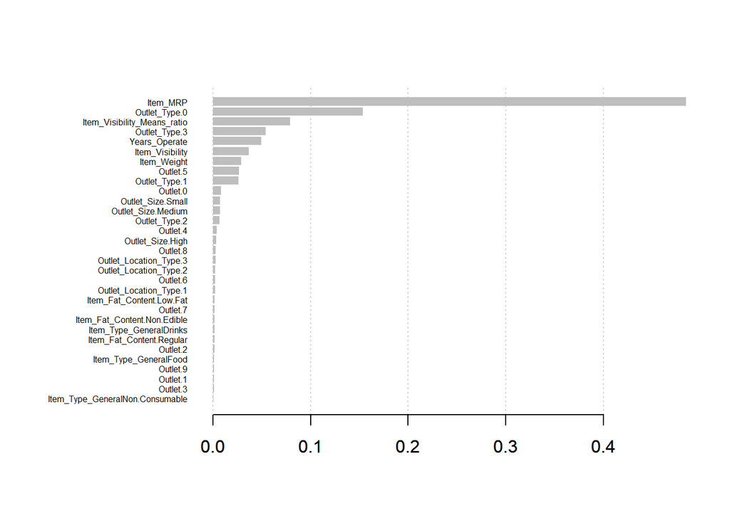

```r
## variance importance

var_imp <- xgb.importance(feature_names = setdiff(names(train4tr),
                                                  c("Item_Identifier",
                                                    "Outlet_Identifier",
                                                    "Item_Outlet_Sales")),
                          model = xgb_fit)

xgb.plot.importance(var_imp)
```

As was expected, the Item_MRP feature is the most important feature in predicting the Item_Outlet_Sales.

## Final Training

The whole training set is trained with the most effective models, XGBoost and Random Forest.

### XGBoost

```r
### Xgb (with the one-hot encoded data set)

param_list <- list(objective = "reg:linear", eta = 0.01, gamma = 1,
                   max_depth = 6, subsample = 0.8, colsample_bytree = 0.5)

dtrain <- xgb.DMatrix(data = data.matrix(train4[,!(names(train4) %in%
                c("Item_Identifier","Outlet_Identifier",
                "Item_Outlet_Sales"))]) ,label = train4$Item_Outlet_Sales)

dtest <- xgb.DMatrix(data = data.matrix(test4[,!(names(test4) %in%                                      c("Item_Identifier","Outlet_Identifier",
                                "Item_Outlet_Sales"))]))

## cross-validation

set.seed(2207)
xgb.cv(params = param_list, data = dtrain, nrounds = 1000, nfold = 5,
       print_every_n = 10, early_stopping_rounds = 30, maximize = FALSE)
```

[output not shown]

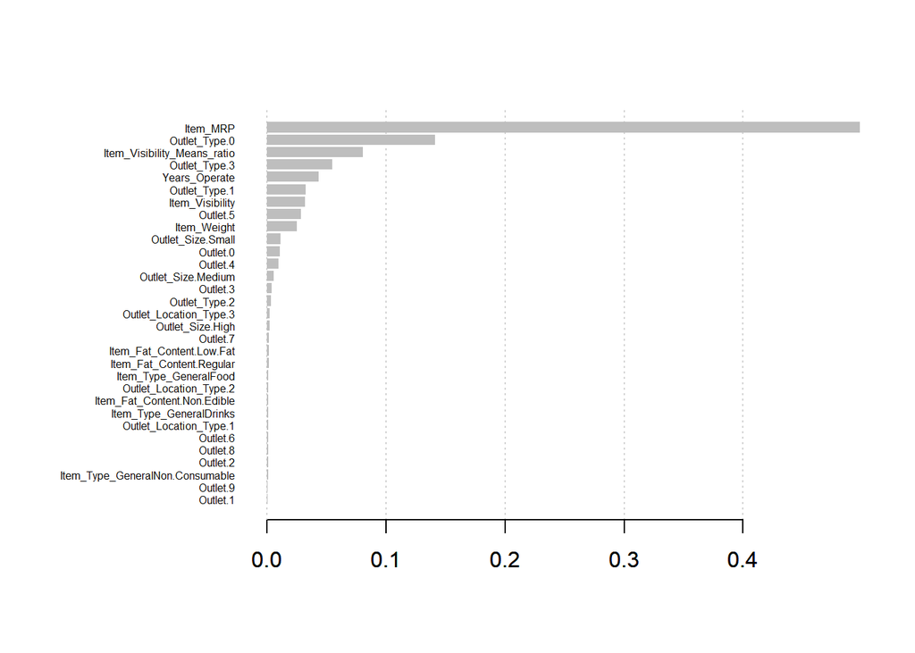

```r
## Best result in iteration 590

set.seed(2207)
xgb_fit_fin <- xgb.train(data = dtrain, params = param_list, nrounds = 590)
xgb.pred_fin <- predict(xgb_fit_fin, newdata = dtest)

## variance importance

var_imp <- xgb.importance(feature_names = setdiff(names(train4),
                                                  c("Item_Identifier",
                                                    "Outlet_Identifier",
                                                    "Item_Outlet_Sales")),
                          model = xgb_fit_fin)

xgb.plot.importance(var_imp)
```

### Random Forest

```r
set.seed(2207)
rf_fit_fin <- randomForest(Item_Outlet_Sales ~ . , data = train3[,-c(1,6)],
                       ntree = 500, nodesize = 100)
rf_fit.pred_fin <- predict(rf_fit_fin, newdata = test3[,-c(1,6)])
```